[figure not shown]

[OHI Science](http://ohi-science.org) | [Citation policy](http://ohi-science.org/citation-policy/)

# Habitats Sub-goal: Coral

OHI+ Palmyra 2020 Assessment

Compiled on Tue Aug 18 12:06:25 2020 by orofino

# Summary

This script uses benthic habitat mapping shapefiles to calculate the percent live coral cover across four regions of interest on the reef to estimate the condition of coral reef habitats.

# Data

Coral cover maps were downloaded from the National Centers for Coastal Ocean Science (NCCOS) benthic habitat mapping project for Palmyra Atoll, found [here.](https://products.coastalscience.noaa.gov/collections/benthic/e58palmyra/#horizontalTab3)

Habitat maps were completed in December 2011 and data were downloaded on June 30, 2020.

Citation: U.S. Department of Commerce, National Oceanic and Atmospheric Administration, National Center for Coastal Ocean Sciences. (2011). Palmyra Habitat Maps [Data file]. Retrieved from https://products.coastalscience.noaa.gov/collections/benthic/e58palmyra/

Lagoon maps for adjusting the area of the lagoon where live coral can reasonably grow were obtained from Alex Wegmann at The Nature Conservancy on August 18, 2020.

# Setup

```r
library(tidyverse)
library(janitor)
library(sf)
library(raster)
library(pals)
library(here)

# Source and set file paths
source(here('src/R/common.R'))

dir_goal   <- '~/github/pal-prep/prep/bd/hab/v2020'
```

# Methods

## Get Coral Cover Maps

Cover categories in the raw data are adapted to a numeric scale as follows:

- 0 - <10% = 1
- 10% - <50% = 2
- 50% - <90% = 3
- 90% - 100% = 4

The following zones are grouped together to form the four major reef zone of interest:

- Back Reef: Not grouped with any other zone
- Reef Crest: Reef Crest and Fore Reef
- Fore Reef: Bank/Shelf and Bank/Shelf Escarpment
- Lagoon: Lagoon and Channel

The fore reef is reassigned to part of the reef crest to better reflect the position of those data points on the reef. The Bank/Shelf and Bank/Shelf Escarpment are then grouped together and renamed as the fore reef with an additional designation to differentiate the western fore reef and the eastern fore reef. These groupings follow the zones delineated by NOAA in the Coral Reef Ecosystems Monitoring Report for the Pacific Remote Islands Marine National Monument, available [here](https://repository.library.noaa.gov/view/noaa/23421).

```r
hab_map <- st_read(file.path(dir_anx, '_raw_data/NCCOS_data/habitat_map'),
                   layer = "Palmyra_Habitat_Map_Final") %>%
  st_transform(wgs84)

# Interested in the coral cover map which is column 'P_CORAL_CV'
coral_map <- hab_map %>%
  clean_names() %>% # lower case column names
  filter(zone != "Unknown",
         p_coral_cv != "Unknown") %>%
  dplyr::select(zone, p_coral_cv, area)

#plot(coral_map)

# Extract the percent coral cover for each zone
zones <- coral_map %>%
  filter(zone == "Back Reef" | zone == "Fore Reef" | zone == "Lagoon" |
         zone == "Bank/Shelf" | zone == "Channel" | zone == "Reef Crest" |
         zone == "Bank/Shelf Escarpment") %>%
  filter(p_coral_cv != "N/A") %>%
  mutate(zone = as.character(zone),
         p_coral_cv = as.character(p_coral_cv),
         zone = ifelse(zone == "Fore Reef", "Reef Crest", zone),
         zone = ifelse(zone == "Bank/Shelf", "Fore Reef", zone),
         zone = ifelse(zone == "Bank/Shelf Escarpment", "Fore Reef", zone),
         zone = ifelse(zone == "Channel", "Lagoon", zone)) %>%
  mutate(cover_cat = case_when(p_coral_cv == "90% - 100%" ~ 4,
                               p_coral_cv == "50% - <90%" ~ 3,
                               p_coral_cv == "10% - <50%" ~ 2,
                               p_coral_cv == "0% - <10%"  ~ 1))
```

## Plot Maps

Original data vs. reclassified data for zones and live coral cover percentage in those zones.

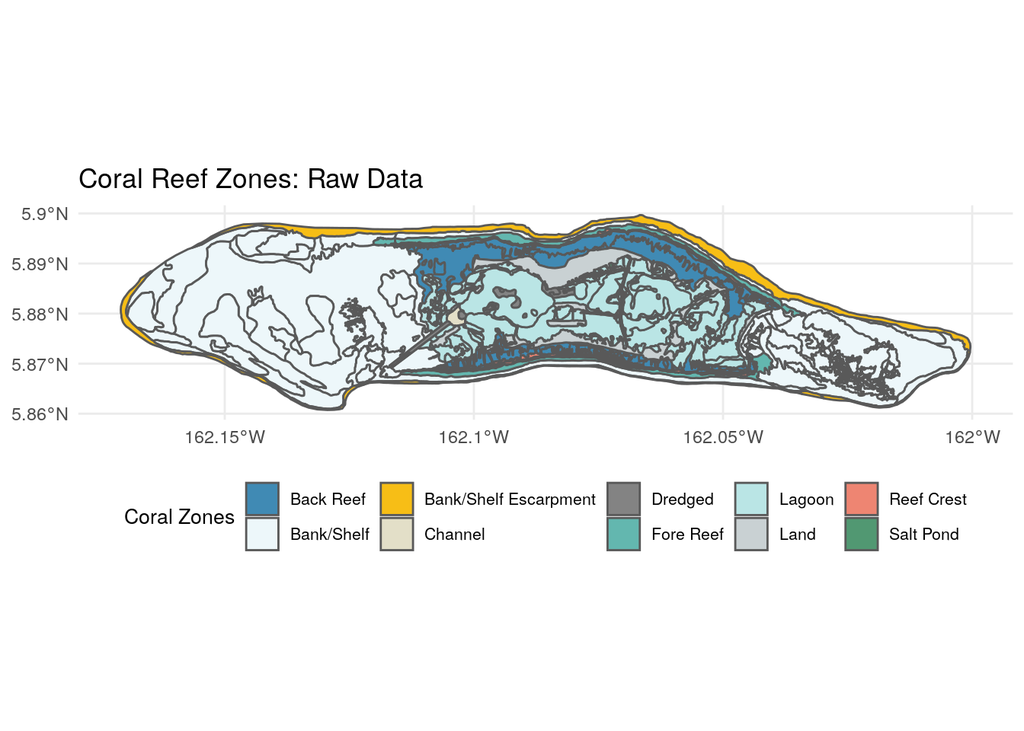

```r
# Coral zones - original data
zones_og <- ggplot() +
  geom_sf(data = coral_map, aes(fill = zone)) +
  scale_fill_manual(breaks = c("Back Reef", "Bank/Shelf",
                               "Bank/Shelf Escarpment", "Channel",
                               "Dredged", "Fore Reef", "Lagoon",
                               "Land", "Reef Crest", "Salt Pond"),
                    values = c("#408ab4", "#edf7fa",
                               "#f7be16", "#e3dfc8",
                               "#838383", "#63b7af", "#bae5e5",
                               "#c9d1d3", "#ee8572", "#519872")) +
  labs(fill = "Coral Zones",
       title = "Coral Reef Zones: Raw Data") +
  theme_minimal() +
  theme(legend.position = "bottom",
        legend.text = element_text(size = 8),
        legend.title = element_text(size = 10),
        legend.key = element_rect(fill = "transparent", colour = "transparent"),
        panel.background = element_rect(fill = "transparent",colour = NA),
        plot.background = element_rect(fill = "transparent",colour = NA),
        legend.background = element_blank(),
        legend.box.background = element_blank())

# Coral zones - reclassified
zones_reclass <- ggplot() +
  geom_sf(data = zones, aes(fill = zone)) +
  scale_fill_manual(breaks = c("Back Reef", "Fore Reef",
                               "Lagoon", "Reef Crest"),
                    values = c("#408ab4", "#63b7af",
                               "#bae5e5", "#ee8572")) +
  labs(fill = "Coral Zones",
       title = "Coral Reef Zones: Reclassified") +
  theme_minimal() +
  theme(legend.position = "bottom",
        legend.text = element_text(size = 8),
        legend.title = element_text(size = 10),
        legend.key = element_rect(fill = "transparent", colour = "transparent"),
        panel.background = element_rect(fill = "transparent",colour = NA),
        plot.background = element_rect(fill = "transparent",colour = NA),
        legend.background = element_blank(),
        legend.box.background = element_blank())

# Coral cover percent - original data
cover_og <- ggplot() +
  geom_sf(data = coral_map, aes(fill = p_coral_cv)) +
  scale_fill_manual(breaks = c("0% - <10%", "10% - <50%",
                               "50% - <90%", "90% - 100%",
                               "NA"),
                    values = c("#d2ebcd", "#aed09e",
                               "#64a36f", "#28544b",
                               "#c9d1d3")) +
  labs(fill = "Percent Live\nCoral Cover",
       title = "Live Coral Cover: Raw Data") +
  theme_minimal() +
  theme(legend.position = "bottom",
        legend.text = element_text(size = 8),
        legend.title = element_text(size = 10),
        legend.key = element_rect(fill = "transparent", colour = "transparent"),
        panel.background = element_rect(fill = "transparent",colour = NA),
        plot.background = element_rect(fill = "transparent",colour = NA),
        legend.background = element_blank(),
        legend.box.background = element_blank())

# Coral cover percent - reclassified
cover_reclass <- ggplot() +
  geom_sf(data = zones, aes(fill = p_coral_cv)) +
  scale_fill_manual(breaks = c("0% - <10%", "10% - <50%",
                               "50% - <90%", "90% - 100%",
                               "NA"),
                    values = c("#d2ebcd", "#aed09e",
                               "#64a36f", "#28544b",
                               "#c9d1d3")) +
  labs(fill = "Percent Live\nCoral Cover",
       title = "Live Coral Cover: Reclassified") +
  theme_minimal() +
  theme(legend.position = "bottom",
        legend.text = element_text(size = 8),
        legend.title = element_text(size = 10),
        legend.key = element_rect(fill = "transparent", colour = "transparent"),
        panel.background = element_rect(fill = "transparent",colour = NA),
        plot.background = element_rect(fill = "transparent",colour = NA),
        legend.background = element_blank(),
        legend.box.background = element_blank())


# Print all maps
zones_og
```

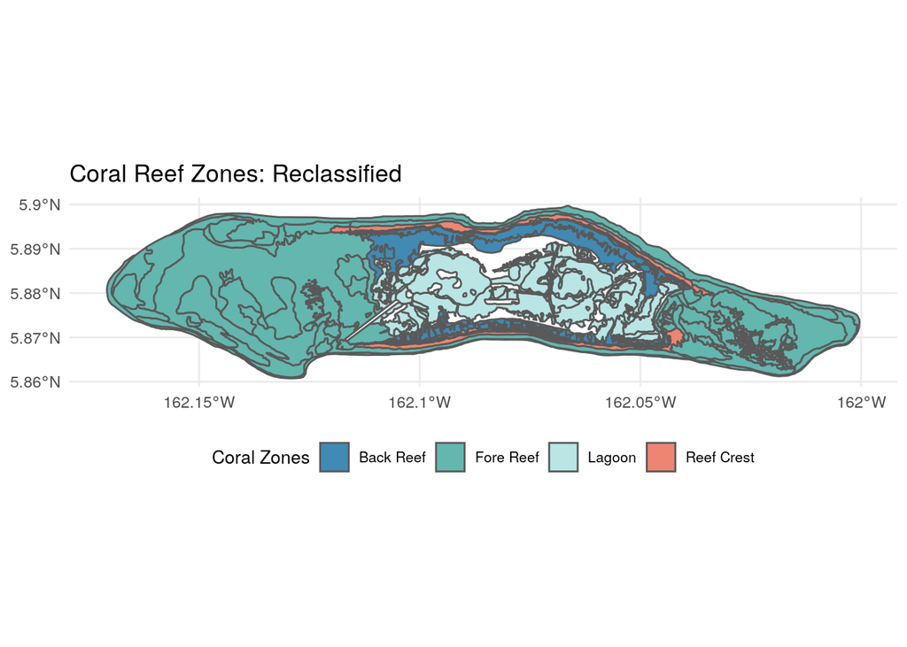

```r
zones_reclass
```

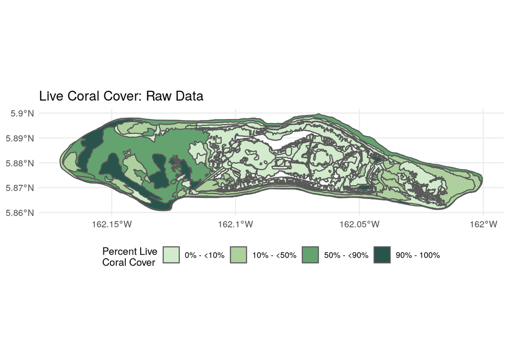

```r
cover_og
```

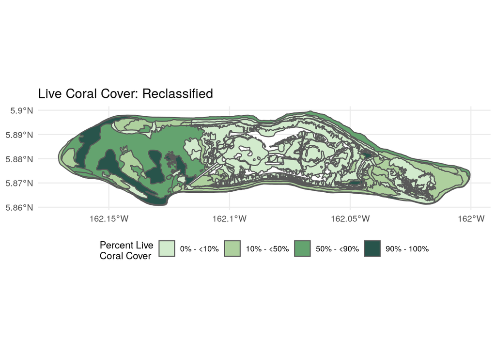

```r
cover_reclass
```

```r
# Save all maps
ggsave(zones_og,
       filename = file.path(dir_goal, "figs/coral_zones_raw.png"),
       bg = "transparent")

ggsave(zones_reclass,
       filename = file.path(dir_goal, "figs/coral_zones_reclassified.png"),
       bg = "transparent")

ggsave(cover_og,
       filename = file.path(dir_goal, "figs/coral_cover_raw.png"),
       bg = "transparent")

ggsave(cover_reclass,
       filename = file.path(dir_goal, "figs/coral_cover_reclassified.png"),
       bg = "transparent")
```

## Fore Reef Zones

The fore reef is further broken down to western and eastern. The fore reef experiences different conditions on the western and eastern side and the percent live coral cover differs largely between the two.

Based on a map of Palmyra, the longitude line 162.075 will be used to divide the fore reef into western and eastern.

```r
fore <- zones %>%
  filter(zone == "Fore Reef")

# Get center of each polygon, break into lat/long
sf_cent <- st_centroid(fore)
sf_cent <- sf_cent %>%
  mutate(lat = unlist(map(sf_cent$geometry,1)),
         long = unlist(map(sf_cent$geometry,2)))

# Plot and make sure these centroids make sense
ggplot() +
  geom_sf(data = fore, fill = "grey") +
  geom_sf(data = sf_cent, color = "red") # Not perfect but it will work for our purposes

# Assign west and east zones based on 162.075 lat line
fore_zones <- fore %>%
  mutate(zone = ifelse(sf_cent$lat < -162.075, "Fore Reef West", "Fore Reef East"))

# Check zones are correct
ggplot() +
  geom_sf(data = fore_zones, aes(fill = p_coral_cv)) # The long N/S are split evenly so that should be fine

## Combine back into the coral zones data frame
zones_combined <- zones %>%
  filter(zone != "Fore Reef") %>% # Filter out fore reef
  rbind(fore_zones)

# Save layer to int folder as shp and csv
st_write(zones_combined, file.path(dir_goal, "int/coral_zones.shp"),
         driver = 'ESRI Shapefile', append=FALSE)
write_csv(zones_combined, file.path(dir_goal, "int/coral_zones.csv"))
```

## Adjust Lagoon Area

Coral status will be area weighted for each of the main four zones. However, the entire lagoon cannot support live coral growth. The area of the lagoon will be adjusted based on shapefiles showing where live coral can reasonably grow. These shapefiles were obtained from Alex Wegmann at The Nature Conservancy on August 18, 2020.

```r
## Read in all lagoon polygon shapefiles
east_line    <- st_read(file.path(dir_anx, 'dataprep/bd/hab/v2020/raw/lagoon_area'),
                   layer = "East_Lagoon_Coral_Potential_5m_Swath-line")

lesley_west  <- st_read(file.path(dir_anx, 'dataprep/bd/hab/v2020/raw/lagoon_area'),
                   layer = "Lesley_West-polygon")

lost_flats   <- st_read(file.path(dir_anx, 'dataprep/bd/hab/v2020/raw/lagoon_area'),
                   layer = "Lost_Flats-polygon")

ns_line      <- st_read(file.path(dir_anx, 'dataprep/bd/hab/v2020/raw/lagoon_area'),
                   layer = "N_S_FS_Coral_Potential_5m_Swath-line")

north_garden <- st_read(file.path(dir_anx, 'dataprep/bd/hab/v2020/raw/lagoon_area'),
                   layer = "North_Coral_Gardens-polygon")

sand_south   <- st_read(file.path(dir_anx, 'dataprep/bd/hab/v2020/raw/lagoon_area'),
                   layer = "Sand_South-polygon")

south_garden <- st_read(file.path(dir_anx, 'dataprep/bd/hab/v2020/raw/lagoon_area'),
                   layer = "South_Coral_Gardens-polygon")

turtle_hole  <- st_read(file.path(dir_anx, 'dataprep/bd/hab/v2020/raw/lagoon_area'),
                   layer = "Turtle_Hole_Flats-polygon")

turtle_line  <- st_read(file.path(dir_anx, 'dataprep/bd/hab/v2020/raw/lagoon_area'),
                   layer = "Turtle_Hole_Potential_Coral_5m_Swath-line")

west_barren  <- st_read(file.path(dir_anx, 'dataprep/bd/hab/v2020/raw/lagoon_area'),
                   layer = "West_Barren_Lagoon-polygon")

west_line    <- st_read(file.path(dir_anx, 'dataprep/bd/hab/v2020/raw/lagoon_area'),
                   layer = "West_Lagoon_Coral_Potential_5m_Swath-line")

# Combine to form one shapefile - find the area
lagoon <- east_line %>%
  rbind(lesley_west) %>%
  rbind(lost_flats) %>%
  rbind(ns_line) %>%
  rbind(north_garden) %>%
  rbind(sand_south) %>%
  rbind(south_garden) %>%
  rbind(turtle_hole) %>%
  rbind(turtle_line) %>%
  rbind(west_barren) %>%
  rbind(west_line) %>%
  mutate(zone = "Lagoon") %>%
  mutate(area_m2 = st_area(.),
         area_km2 = area_m2 * 0.000001) %>%
  separate(area_km2, into = c("area_km2", "units"), sep = " ") %>%
  dplyr::select(site = Name, zone, area_km2)
# No area for the line features

# Find area of line features
lagoon_lines   <- lagoon %>%
  filter(area_km2 == 0) %>%  # Should be 4
  dplyr::select(-area_km2) %>%
  mutate(length_m = st_length(.),
         width_m = 5) %>%
  separate(length_m, into = c("length_m", "units"), sep = " ") %>%
  mutate(length_m = as.numeric(length_m),
         area_km2 = (length_m * width_m) * 0.000001) %>%
  dplyr::select(site, zone, area_km2)

# Isolate the lagoon polygons
lagoon_noline <- lagoon %>%
  filter(area_km2 != 0)

# Convert both objects to multilinestrings to combine
lagoon_mln <- st_cast(lagoon_noline, "MULTILINESTRING", do_split = FALSE)
lines_mln  <- st_cast(lagoon_lines, "MULTILINESTRING", do_split = FALSE)

# Combine
lagoon_all <- rbind(lagoon_mln, lines_mln) %>%
  mutate(area_km2 = as.numeric(area_km2))

## Find total area of lagoon
lagoon_area <- data.frame(
  zone = "Lagoon",
  area_km2 = sum(lagoon_all$area_km2))

# Save shp and csv to int folder
st_write(lagoon_all, file.path(dir_goal, "int/lagoon_area.shp"),
         append=FALSE)
write_csv(lagoon_area, file.path(dir_goal, "int/lagoon_area.csv"))
```

## Calculate Coral Status

**Reference Points:** Reference points were established for each coral zone:

- Back Reef: 10-50%
- Reef Crest: 10-50%
- Fore Reef: 50-90%
- Lagoon: 10-50%

Coral reef status is first calculated for each zone. The status is calculated as the area of the reef zone falling within or above the reference point category divided by the total area of the reef zone, as in the following equation:

$status_{zone}~=~ref_{area}~/~total_{area}$

Where $ref_{area}$ is the area of the reef zone falling within or above the reference point category and $total_{area}$ is the total area of the reef zone. The total area of the lagoon has been adjusted for the status calculation to include only the area of the lagoon where coral could reasonably grow.

The overall status score is calculated as the area weighted mean of the status score for each zone. For this calculation, the total area of the lagoon is used.

```r
zones       <- read_csv(file.path(dir_goal, "int/coral_zones.csv"))
lagoon_area <- read_csv(file.path(dir_goal, "int/lagoon_area.csv"))

# Define reference point categories
ref_back  <- 2
ref_crest <- 2
ref_fore  <- 3
ref_lag   <- 2

# Total area for each zone
tot_areas <- zones %>%
  group_by(zone) %>%
  summarize(tot_area_km = sum(area) * 0.000001) %>%
  mutate(tot_area_km = ifelse(zone == "Lagoon",
                              lagoon_area$area_km2, tot_area_km)) # Use adjusted lagoon area

lagoon_old <- 10.464687 # Total lagoon area for overall score

# Area in each zone where cover_cat = ref, or cover_cat > ref
zone_area <- zones %>%
  mutate(area_km = area * 0.000001) %>%
  group_by(zone) %>%
  mutate(ref = case_when(zone == "Back Reef" ~ ref_back,
                         zone == "Reef Crest" ~ ref_crest,
                         zone == "Fore Reef West" ~ ref_fore,
                         zone == "Fore Reef East" ~ ref_fore,
                         zone == "Lagoon" ~ ref_lag)) %>%
  filter(ref == cover_cat | cover_cat > ref) %>%
  group_by(zone) %>%
  summarize(area_km = sum(area_km)) %>%
  left_join(tot_areas, by = "zone")

# Find the status
coral_status <- zone_area %>%
  mutate(status = area_km / tot_area_km,
         region_id = 1,
         year = 2011,
         habitat = "coral") %>%
  mutate(tot_area_km = ifelse(zone == "Lagoon",
                              lagoon_old, tot_area_km)) %>% # Use total lagoon area
  dplyr::select(region_id, habitat, year, zone, area_km = tot_area_km, status)

# Save to output
write_csv(coral_status, file.path(dir_goal, "output/coral_status.csv"))
```

## Coral Habitat Extent

Find the extent (km<sup>2</sup>) of entire coral reef habitat. This extent is used in creating weights for pressures and resilience.

```r
zones <- read_csv(file.path(dir_goal, "int/coral_zones.csv"))

# Find total area for the four zones of interest:
zone_areas <- zones %>%
  group_by(zone) %>%
  summarize(tot_area_km = sum(area) * 0.000001)

# Create a dataframe with total extent:
coral_extent <- data.frame(
  region_id = 1,
  habitat = "coral",
  year = 2011,
  km2 = sum(zone_areas$tot_area_km)
)

# Save to output folder:
write_csv(coral_extent, file.path(dir_goal, "output/coral_extent.csv"))
```

## Save to Toolbox

Save both the extent and status layers to toolbox.

```r
# Read in files
coral_extent <- read_csv(file.path(dir_goal, "output/coral_extent.csv"))
coral_status <- read_csv(file.path(dir_goal, "output/coral_status.csv"))

# Write to toolbox
write_csv(coral_extent, file.path(dir_scores, "layers/hab_coral_extent.csv"))
write_csv(coral_status, file.path(dir_scores, 'layers/hab_coral_status.csv'))
```